# PRA 2: Neteja, validació i anàlisi de les dades

Álvaro Díaz i David Leiva

13/12/2020

# 1 Detalls de l’activitat

## 1.1 Presentació

En aquesta pràctica s’elabora un cas pràctic orientat a aprendre a identificar les dades rellevants per un projecte analític i usar les eines d’integració, neteja, validació i anàlisi de les mateixes

## 1.2 Competències

En aquesta pràctica es desenvolupen les següents competències del Màster de Data Science:

- Capacitat d’analitzar un problema en el nivell d’abstracció adequat a cada situació i aplicar les habilitats i coneixements adquirits per abordar-lo i resoldre’l.
- Capacitat per aplicar les tècniques específiques de tractament de dades (integració,transformació, neteja i validació) per al seu posterior anàlisi.

## 1.3 Objectius

Els objectius concrets d’aquesta pràctica són:

- Aprendre a aplicar els coneixements adquirits i la seva capacitat de resolució de problemes en entorns nous o poc coneguts dintre de contextos més amplis o multidisciplinaris.
- Saber identificar les dades rellevants i els tractaments necessaris (integració, neteja i validació) per dur a terme un projecte analític.
- Aprendre a analitzar les dades adequadament per abordar la informació continguda en les dades.
- Identificar la millor representació dels resultats per tal d’aportar conclusions sobre el problema plantejat en el procés analític.
- Actuar amb els principis ètics i legals relacionats amb la manipulació de dades en funció de l’àmbit d’aplicació.
- Desenvolupar les habilitats d’aprenentatge que els permetin continuar estudiant d’una manera que haurà de ser en gran manera autodirigida o autònoma.
- Desenvolupar la capacitat de cerca, gestió i ús d’informació i recursos en l’àmbit de la ciència de dades.

# 2 Resolució

## 2.1 Descripció del dataset

Es realitzarà l’anàlisi exploratori (EDA) del dataset https://archive.ics.uci.edu/ml/datasets/HCC+Survival on es recopila informació de pacients amb carcinoma hepatocelullar (HCC) i la seva supervivència a l’any.

L’HCC és el tumor hepàtic més comú en els pacients amb hepatopatia crónica. La supervivència d’aquests pacients no només depen de l’estadi tumoral si no que també depen de l’estat funcional del fetge.

El conjunt de dades HCC es va obtenir en l´’Hospital Universitari de Coïmbra (Portugal) i contenia diversos factors demogràfics, de risc, de laboratori i de supervivència global de 165 pacients reals diagnosticats de HCC. El conjunt de dades conté 49 funcions seleccionades segons les directrius de pràctica clínica EASL-EORTC (Associació Europea per a l’Estudi del Fetge - Organització Europea per a la Recerca i el Tractament del Càncer), que són els habituals en la gestió de HCC.

Es tracta d’un conjunt de dades heterogeni, amb 23 variables quantitatives i 26 variables qualitatives. La variable objectiu és la supervivència a 1 any i es va codificar com a variable binària: 0 (mor) i 1 (viu).

Les variables del dataset són:

- **Gender (Gen)**: [1=Home;0=Dona] Sexe del pacient
- **Symptoms (Sym)**:[1=Si;0=No] Sintomàtic
- **Alcohol (Alc)**: [1=Si;0=No] Hepatopatia alcohòlica
- **Hepatitis B Surface Antigen (HBS)**: [1=Si;0=No] Antigen de superfície de l’hepatitis B present a la sang
- **Hepatitis B e Antigen (HBe)**:[1=Si;0=No] Antigen e de l’hepatitis B present a la sang
- **Hepatitis B Core Antibody (HBC)**: [1=Si;0=No] Anticòs per l’hepatitis B present a la sang
- **Hepatitis C Virus Antibody (HCV)**: [1=Si;0=No] Anticòs per l’hepatitis C present a la sang
- **Cirrhosis (Cir)**: [1=Si;0=No] Estadio avançat d’hepatopatia crónica
- **Endemic Countries (End)**: [1=Si;0=No] Pacient procedent de països amb alta prevalença d’hepatitis vírica
- **Smoking (Smo)**: [1=Si;0=No] Fumador
- **Diabetes (Dia)**: [1=Si;0=No] Diabètic
- **Obesity (Obe)**: [1=Si;0=No] Obesitat
- **Hemochromatosis (Hem)**:[1=Si;0=No] Hemocromatosi
- **Arterial Hypertension (HyA)**: [1=Si;0=No] Hipertensió arterial
- **Chronic Renal Insufficiency(CRI)**: [1=Si;0=No] Insuficiència renal
- **Human Immunodeficiency Virus (HIV)**: [1=Si;0=No] Infecció per HIV
- **Nonalcoholic Steatohepatitis (Ste)**: [1=Si;0=No] Esteatosis hepàtica de origen no alcohòlic
- **Esophageal Varices (Eso)**: [1=Si;0=No] Presència de varius esofàgiges com indicador d’hipertensió portal
- **Splenomegaly (Spl)**: [1=Si;0=No] Augment del tamany de la melsa com indicador d’hipertensió portal
- **Portal Hypertension (PHT)**: [1=Si;0=No] Pacient amb hipertensió arterial coneguda
- **Portal Vein Thrombosis (PVT)**: [1=Si;0=No] Presència de trombosi venosa portal
- **Liver Metastasis (Met)**: [1=Si;0=No] Metàstasi hepàtica
- **Radiological Hallmark (Rad)**: [1=Si;0=No]Comportament radiològic típic per HCC
- **Age at diagnosis (Age)**: Anys d’edat al moment del diagnóstic de HCC
- **Grams of Alcohol per day (gAl)**: Grams d’alcohol ingerit de mitjana al dia
- **Packs of cigarets per year (PCi)**: Número de paquets de cigarrets consumits per any
- **Performance Status (PSt)**: [0=Activo;1=Restringit;2=Asistencia ocasional;3=Asistencia parcial;4=Asistencia total;5=Mort] Escala de l’estat general del pacient oncològic
- **Encephalopathy degree (Enc)**: [1=Cap;2=Grau I/II; 3=Grau III/IV] Grau d’afectació mental de l’hepatopatia
- **Ascites degree (Asc)**: [1=Cap;2=Lleu;3=Moderada a Severa] Grau d’ascitis com a indicador indirecte d’hipertensió portal
- **International Normalised Ratio (INR)**: Temps de protrombina
- **Alpha-Fetoprotein (ng/mL) (AFe)**: Nivells del marcador tumoral a la sang
- **Haemoglobin (g/dL) (Hae)**: Nivells de Hemoglobina a la sang
- **Mean Corpuscular Volume (MCV)**: Volum corpuscular mig dels eritrocits
- **Leukocytes(G/L) (Leu)**: Concentració de cél.lules blanques en sang
- **Platelets (Pla)**: Concentració de plaquestes en sang
- **Albumin (mg/dL) (Alb)**: Nivelss d’albumina en sang
- **Total Bilirubin(mg/dL) (BiT)**: Nivells de Bilirrubina Total en sang
- **Alanine transaminase (U/L) (ALT)**: Nivells d’ALT en sang
- **Aspartate transaminase (U/L) (AST)**: Nivells d’ASP en sang
- **Gamma glutamyl transferase (U/L) (GGT)**: Nivells gamma-GT en sang
- **Alkaline phosphatase (U/L) (ALP)**: Nivelss de fosfatasa alcalina en sang
- **Total Proteins (g/dL) (Pro)**: Concentració total de proteïnes en sang
- **Creatinine (mg/dL) (Crea)**: Concentració de creatinina en sang
- **Number of Nodules (Nod)**: Número de nóduls d’HCC visualitzats
- **Major dimension of nodule (cm) (DiN)**: Tamany major dels nóduls d’HCC
- **Direct Bilirubin (mg/dL) (BiD)**: Nivells de Bilirrubina Directe en sang
- **Iron (Iro)**: Concentració de ferro en sang
- **Oxygen Saturation (%) (OxS)**: Saturació d’oxigen de la sang
- **Ferritin (ng/mL) (Fer)**: Nivells de ferritina en sang
- **Class Attribute (Class)**:[0=Mort; 1=Viu] Supervivent a l’any del diagnóstic d’HCC

## 2.2 Importància i objectius de l’anàlisi

Amb les dades recopilades al dataset podem intentar saber quines variables estan més relacionades amb la supervivència a l’any. Podem conèixer el grau de correlació entre les variables independents per finalment definir un model de regressió logística per tal d’intentar predir la mortalitat a l’any amb les variables seleccionades.

Poder conèixer la probabilitat de supervivència d’un pacient amb diagnóstic recent d’HCC podrà fer que s’adaptin millors les opcions de tractament, sent més agressius en pacients amb alta probilitat de sobreviure, i en canvi, optant per terapies pal·liatives o de confort per pacients amb pitjor prosnóstic.

## 2.3 Neteja de les dades

### 2.3.1 Preparació del dataset

```r
library(knitr)
library(tidyverse)

# Importació del dataset
download.file("https://archive.ics.uci.edu/ml/machine-learning-databases/00423/hcc-survival.zip","mydata.zip")
unzip("mydata.zip")
hcc<-read.csv ("hcc-survival/hcc-data.txt",header = F, dec = ".", stringsAsFactors = F, na.strings = "?")

# Noms de les variables
hcc_header<-c("Gender", "Symptoms", "Alcohol", "Hepatitis B Surface Antigen",
              "Hepatitis B e Antigen", "Hepatitis B Core Antibody",
              "Hepatitis C Virus Antibody",  "Cirrhosis",
              "Endemic Countries","Smoking",  "Diabetes", "Obesity",
              "Hemochromatosis", "Arterial Hypertension",
              "Chronic Renal Insufficiency", "Human Immunodeficiency Virus",
              "Nonalcoholic Steatohepatitis","Esophageal Varices",
              "Splenomegaly",  "Portal Hypertension",
              "Portal Vein Thrombosis", "Liver Metastasis",
              "Radiological Hallmark", "Age at diagnosis",
              "Grams of Alcohol per day", "Packs of cigarets per year",
              "Performance Status", "Encephalopathy degree", "Ascites degree",
              "International Normalised Ratio", "Alpha-Fetoprotein (ng/mL)",
              "Haemoglobin (g/dL)", "Mean Corpuscular Volume",
              "Leukocytes(G/L)", "Platelets", "Albumin (mg/dL)",
              "Total Bilirubin(mg/dL)",  "Alanine transaminase (U/L)"
              , "Aspartate transaminase (U/L)",
              "Gamma glutamyl transferase (U/L)",
              "Alkaline phosphatase (U/L)","Total Proteins (g/dL)",
              "Creatinine (mg/dL)","Number of Nodules",
              "Major dimension of nodule (cm)",
              "Direct Bilirubin (mg/dL)", "Iron", "Oxygen Saturation (%)",
              "Ferritin (ng/mL)", "Class Attribute"   )

hcc_header_cortos<-c("Gen", "Sym", "Alc", "HBS", "HBe", "HBC","HCV",  "Cir",
               "End","Smo",  "Dia", "Obe", "Hem", "HyA", "CRI", "HIV",
               "Ste","Eso", "Spl",  "PHT", "PVT", "Met", "Rad", "Age", "gAl",
               "PCi", "PSt", "Enc", "Asc", "INR", "AFe", "Hae", "MCV",  "Leu",
               "Pla", "Alb","BiT",  "ALT", "AST","GGT", "ALP","Pro",
               "Crea","Nod",  "DiN", "BiD", "Iro", "OxS", "Fer", "Class"   )

colnames(hcc)<-hcc_header
str(hcc)
```

```
## 'data.frame':    165 obs. of  50 variables:
##  $ Gender                          : int  1 0 1 1 1 1 1 1 1 1 ...
##  $ Symptoms                        : int  0 NA 0 1 1 0 0 1 1 1 ...
##  $ Alcohol                         : int  1 0 1 1 1 1 0 1 1 1 ...
##  $ Hepatitis B Surface Antigen     : int  0 0 1 0 1 0 0 0 0 0 ...
##  $ Hepatitis B e Antigen           : int  0 0 0 0 0 NA NA NA 0 0 ...
##  $ Hepatitis B Core Antibody       : int  0 0 1 0 1 0 1 0 0 0 ...
##  $ Hepatitis C Virus Antibody      : int  0 1 0 0 0 0 1 0 0 0 ...
##  $ Cirrhosis                       : int  1 1 1 1 1 1 1 1 1 1 ...
##  $ Endemic Countries               : int  0 NA 0 0 0 0 0 0 0 0 ...
##  $ Smoking                         : int  1 NA 1 1 1 NA 0 1 1 0 ...
##  $ Diabetes                        : int  1 1 0 1 0 0 1 1 1 0 ...
##  $ Obesity                         : int  NA 0 0 0 0 1 0 NA 0 0 ...
##  $ Hemochromatosis                 : int  1 0 0 0 0 0 NA 0 0 1 ...
##  $ Arterial Hypertension           : int  0 1 1 1 1 0 0 0 1 0 ...
```

[output cut: 36 more lines]

```r
summary(hcc)
```

```
##      Gender          Symptoms         Alcohol
##  Min.   :0.0000   Min.   :0.0000   Min.   :0.0000
##  1st Qu.:1.0000   1st Qu.:0.0000   1st Qu.:0.0000
##  Median :1.0000   Median :1.0000   Median :1.0000
##  Mean   :0.8061   Mean   :0.6395   Mean   :0.7394
##  3rd Qu.:1.0000   3rd Qu.:1.0000   3rd Qu.:1.0000
##  Max.   :1.0000   Max.   :1.0000   Max.   :1.0000
##                   NA's   :18
##  Hepatitis B Surface Antigen Hepatitis B e Antigen
##  Min.   :0.0000              Min.   :0.00000
##  1st Qu.:0.0000              1st Qu.:0.00000
##  Median :0.0000              Median :0.00000
##  Mean   :0.1081              Mean   :0.00794
##  3rd Qu.:0.0000              3rd Qu.:0.00000
##  Max.   :1.0000              Max.   :1.00000
##  NA's   :17                  NA's   :39
##  Hepatitis B Core Antibody Hepatitis C Virus Antibody   Cirrhosis
##  Min.   :0.0000            Min.   :0.0000             Min.   :0.000
##  1st Qu.:0.0000            1st Qu.:0.0000             1st Qu.:1.000
##  Median :0.0000            Median :0.0000             Median :1.000
##  Mean   :0.2695            Mean   :0.2179             Mean   :0.903
##  3rd Qu.:1.0000            3rd Qu.:0.0000             3rd Qu.:1.000
##  Max.   :1.0000            Max.   :1.0000             Max.   :1.000
##  NA's   :24                NA's   :9
##  Endemic Countries    Smoking          Diabetes         Obesity
##  Min.   :0.00000   Min.   :0.0000   Min.   :0.0000   Min.   :0.000
##  1st Qu.:0.00000   1st Qu.:0.0000   1st Qu.:0.0000   1st Qu.:0.000
##  Median :0.00000   Median :1.0000   Median :0.0000   Median :0.000
##  Mean   :0.07937   Mean   :0.5081   Mean   :0.3457   Mean   :0.129
##  3rd Qu.:0.00000   3rd Qu.:1.0000   3rd Qu.:1.0000   3rd Qu.:0.000
##  Max.   :1.00000   Max.   :1.0000   Max.   :1.0000   Max.   :1.000
##  NA's   :39        NA's   :41       NA's   :3        NA's   :10
##  Hemochromatosis  Arterial Hypertension Chronic Renal Insufficiency
##  Min.   :0.0000   Min.   :0.0000        Min.   :0.0000
##  1st Qu.:0.0000   1st Qu.:0.0000        1st Qu.:0.0000
##  Median :0.0000   Median :0.0000        Median :0.0000
##  Mean   :0.0493   Mean   :0.3642        Mean   :0.1227
##  3rd Qu.:0.0000   3rd Qu.:1.0000        3rd Qu.:0.0000
##  Max.   :1.0000   Max.   :1.0000        Max.   :1.0000
##  NA's   :23       NA's   :3             NA's   :2
```

[output cut: 89 more lines]

```
##  Min.   : 1.500                 Min.   : 0.10            Min.   :  0.0
##  1st Qu.: 3.000                 1st Qu.: 0.37            1st Qu.: 40.5
##  Median : 5.000                 Median : 0.70            Median : 83.0
##  Mean   : 6.851                 Mean   : 1.93            Mean   : 85.6
##  3rd Qu.: 9.000                 3rd Qu.: 1.40            3rd Qu.:118.0
##  Max.   :22.000                 Max.   :29.30            Max.   :224.0
##  NA's   :20                     NA's   :44               NA's   :79
##  Oxygen Saturation (%) Ferritin (ng/mL) Class Attribute
##  Min.   :  0.00        Min.   :   0     Min.   :0.0000
##  1st Qu.: 16.00        1st Qu.:  84     1st Qu.:0.0000
##  Median : 27.00        Median : 295     Median :1.0000
##  Mean   : 37.03        Mean   : 439     Mean   :0.6182
##  3rd Qu.: 56.00        3rd Qu.: 706     3rd Qu.:1.0000
##  Max.   :126.00        Max.   :2230     Max.   :1.0000
##  NA's   :80            NA's   :80
```

### 2.3.2 Descripció del dataset

El dataset està compost de 165 observacions de 49 atributs de pacients amb una variable de classe que registra la supervivència a l’any del diagnóstic. Dels atributs dels pacients, existeixen 26 categorics, 3 dels quals són ordinals ( *Performance Status*, *Encephalopathy degree*, *Ascites degree*), sent la resta numérics. És pot veure que existeixen valors nuls codificats com *NA*.

```r
# Definició de tipus de dades per columna
hcc_factor <-c(1:23,50)
hcc_order <- c(27:29)
hcc_factorT<-c(1:23,27:29,50)
hcc_num<-c(24:26,30:49)

# Factorització de les columnes categóriques

hcc <- hcc %>% mutate_at(vars(c(1:23,50)), as.factor)
hcc <- hcc %>% mutate_at(vars(c(27:29)), as.factor)
```

### 2.3.3 Valors nuls

```r
## NA

### Distribució de valors desconeguts per pacient
print("Distribució de valors desconeguts per pacient")
```

```
## [1] "Distribució de valors desconeguts per pacient"
```

```r
table(apply(hcc, 1, function(x) sum(is.na(x))))
```

```
##
##  0  1  2  3  4  5  6  7  8  9 10 11 12 13 14 16 18 22 23
##  8 16 15 28 19 21 15  7 11 12  4  2  1  1  1  1  1  1  1
```

```r
# Valores NA por variable
print("Distribució de valors desconeguts per variable")
```

```
## [1] "Distribució de valors desconeguts per variable"
```

```r
table(colSums(is.na(hcc)))
```

```
##
##  0  1  2  3  4  5  6  7  8  9 10 11 14 15 17 18 20 22 23 24 39 41 44 48 52
##  6  1  4 10  3  1  1  1  1  1  1  2  1  1  1  1  1  1  1  1  2  1  1  1  1
## 53 79 80
##  1  1  2
```

```r
sort (colSums(is.na(hcc)), decreasing = TRUE)
```

```
##            Oxygen Saturation (%)                 Ferritin (ng/mL)
##                               80                               80
##                             Iron       Packs of cigarets per year
##                               79                               53
##               Esophageal Varices         Grams of Alcohol per day
##                               52                               48
##         Direct Bilirubin (mg/dL)                          Smoking
##                               44                               41
##            Hepatitis B e Antigen                Endemic Countries
##                               39                               39
##        Hepatitis B Core Antibody                  Hemochromatosis
##                               24                               23
##     Nonalcoholic Steatohepatitis   Major dimension of nodule (cm)
##                               22                               20
##                         Symptoms      Hepatitis B Surface Antigen
##                               18                               17
##                     Splenomegaly     Human Immunodeficiency Virus
##                               15                               14
##              Portal Hypertension            Total Proteins (g/dL)
##                               11                               11
##                          Obesity       Hepatitis C Virus Antibody
##                               10                                9
##        Alpha-Fetoprotein (ng/mL)               Creatinine (mg/dL)
##                                8                                7
##                  Albumin (mg/dL)           Total Bilirubin(mg/dL)
##                                6                                5
##                 Liver Metastasis   International Normalised Ratio
##                                4                                4
##       Alanine transaminase (U/L)                         Diabetes
##                                4                                3
##            Arterial Hypertension           Portal Vein Thrombosis
##                                3                                3
##               Haemoglobin (g/dL)          Mean Corpuscular Volume
##                                3                                3
##                  Leukocytes(G/L)                        Platelets
##                                3                                3
##     Aspartate transaminase (U/L) Gamma glutamyl transferase (U/L)
##                                3                                3
##       Alkaline phosphatase (U/L)      Chronic Renal Insufficiency
##                                3                                2
##            Radiological Hallmark                   Ascites degree
##                                2                                2
##                Number of Nodules            Encephalopathy degree
##                                2                                1
##                           Gender                          Alcohol
##                                0                                0
##                        Cirrhosis                 Age at diagnosis
##                                0                                0
##               Performance Status                  Class Attribute
##                                0                                0
```

```r
## REVISAR: Creo que así miramos si hay diferencias de la propia variable no de los valores NA de la variable. Añado después otro código a ver qué te parece

# Valoració de la distribució dels NA a les variables amb >10% de NA amb
# respecte la variable classe
hcc_colNA<-names(hcc[hcc_factor][colSums(is.na(hcc[hcc_factor]))>10])
totFactor <- names(hcc[hcc_factor])
testSig <- tibble()

for (i in totFactor){
    #print(i)
    test<-prop.test(table(hcc[,i],hcc$`Class Attribute`))
    if (test$p.value<0.05){
      testSig <- testSig %>% bind_rows(c(Clase = i, p_value = test$p.value))
    }
    #print(table(hcc[,i],hcc$`Class Attribute`))
    #print (test$p.value)
  }

cat("\nVariables amb una difència significativa de NA entre els grups de la classe\n",testSig$Clase)
```

```
##
## Variables amb una difència significativa de NA entre els grups de la classe
##  Symptoms Portal Vein Thrombosis Liver Metastasis Class Attribute
```

```r
# Valoració de la distribució dels NA a les variables amb respecte la variable classe
cero<-hcc[hcc$`Class Attribute`==0,]
uno<-hcc[hcc$`Class Attribute`==1,]

testSig <- tibble()

for (i in names(hcc[,hcc_factorT]))
{
  if (sum(is.na(hcc[,i]))>0){
    casos<-c(sum(is.na(cero[,i])),sum(is.na(uno[,i])))
    long<-c(length(cero[,i]),length(uno[,i]))
    test<-prop.test(x=casos,n=long)
    if(test$p.value<0.05){
      testSig <- testSig %>% bind_rows(c(Clase = i, p_value = test$p.value, prob_0=(casos/long)[1], prob_1=(casos/long)[2],numNA_0=casos[1], numNA_1=casos[2]))

    }
  }
}

cat("\nVariables amb una difència significativa de NA entre els grups de la classe\n",testSig$Clase)
```

```
##
## Variables amb una difència significativa de NA entre els grups de la classe
##  Symptoms Hemochromatosis Esophageal Varices
```

```r
testSig
```

```
## # A tibble: 3 x 6
##   Clase         p_value         prob_0        prob_1        numNA_0 numNA_1
##   <chr>         <chr>           <chr>         <chr>         <chr>   <chr>
## 1 Symptoms      0.005752488365~ 0.0158730158~ 0.1666666666~ 1       17
## 2 Hemochromato~ 0.001882750322~ 0.2539682539~ 0.0686274509~ 16      7
## 3 Esophageal V~ 0.008363108983~ 0.4444444444~ 0.2352941176~ 28      24
```

A la variable `Symptoms` s’observen molts NA entre els pacients que sobreviuen. Els pacients que no sobreviuen solen presentar molta simptomatologia i aquesta es registra. En canvi, els pacients que no presenten símptomes, poden no registrar-se com a negatiu a aquesta variable, existint un biaix d’informació.

Corregir aquest valors desconeguts cap a la moda condicionarà un biaix. Per tant, per corregir els valors NA es farà:

### 2.3.4 Correcció valors nuls de variables categòriques

```r
# Correcció de NA de variables categóriques amb la moda

# Funció moda
my_mode <- function(x) {
  unique_x <- unique(x)
  tabulate_x <- tabulate(match(x, unique_x))
  unique_x[tabulate_x == max(tabulate_x)]
}

# Correcció NA categórics moda
for (i in hcc_factorT)
  {
    hcc[is.na(hcc[,i]),i]<-(my_mode(hcc[,i]))
}


# Correcció NA categòrics kNN

suppressWarnings(suppressMessages(library(VIM)))
hcc$Symptoms<-kNN(hcc)$Symptoms
hcc$Hemochromatosis<-kNN(hcc)$Hemochromatosis
hcc$`Esophageal Varices`<-kNN(hcc)$`Esophageal Varices`
```

### 2.3.5 Correcció valors nuls de variables quantitatives

Existeixen dues variables amb valors extranys, incompatibles amb la vida; son `Leukocytes` i `Platelets` La gran majoria dels valors a la variable `Leukocytes` esgan per sota de 100, que és l’esperat. Valors majors son pràcticament impossibles. Els valors d’aquesta variable es solen expressar sobre mm3 pel que solen tenir valors múltiples de 1000, d’aquí la probable confusió amb els valors extrems trobats. Es corregiran modificant les unitats d’aquest valors.

Amb respecte `Platelets`, l’error és similar al trobat a l’anterior variable.

```r
# Correcció valors leucocitosi i plaquetes
hcc$`Leukocytes(G/L)`[!is.na(hcc$`Leukocytes(G/L)`)&hcc$`Leukocytes(G/L)`>100]<-hcc$`Leukocytes(G/L)`[!is.na(hcc$`Leukocytes(G/L)`)&hcc$`Leukocytes(G/L)`>100]/1000

hcc$Platelets[!is.na(hcc$Platelets)&hcc$Platelets<1000]<-hcc$Platelets[!is.na(hcc$Platelets)&hcc$Platelets<1000]*1000

# Correcció NA amb mitjana
for (i in hcc_num){
  hcc[is.na(hcc[,i]),i]<-median(hcc[,i],na.rm = TRUE)
}
```

## 2.4 Anàlisi de les dades

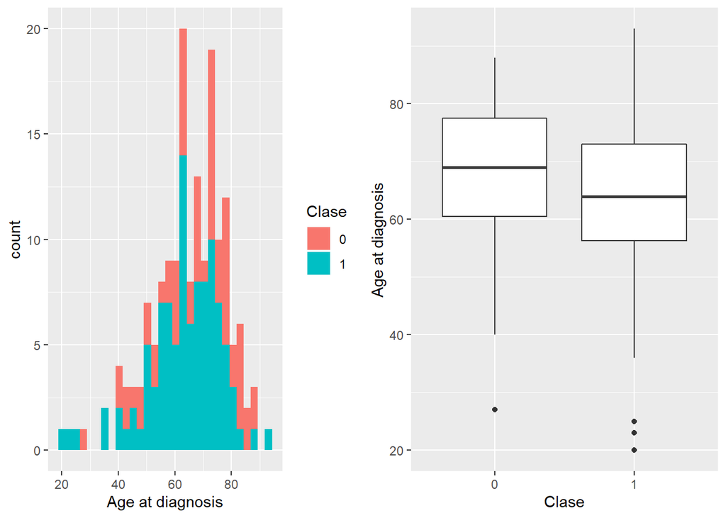

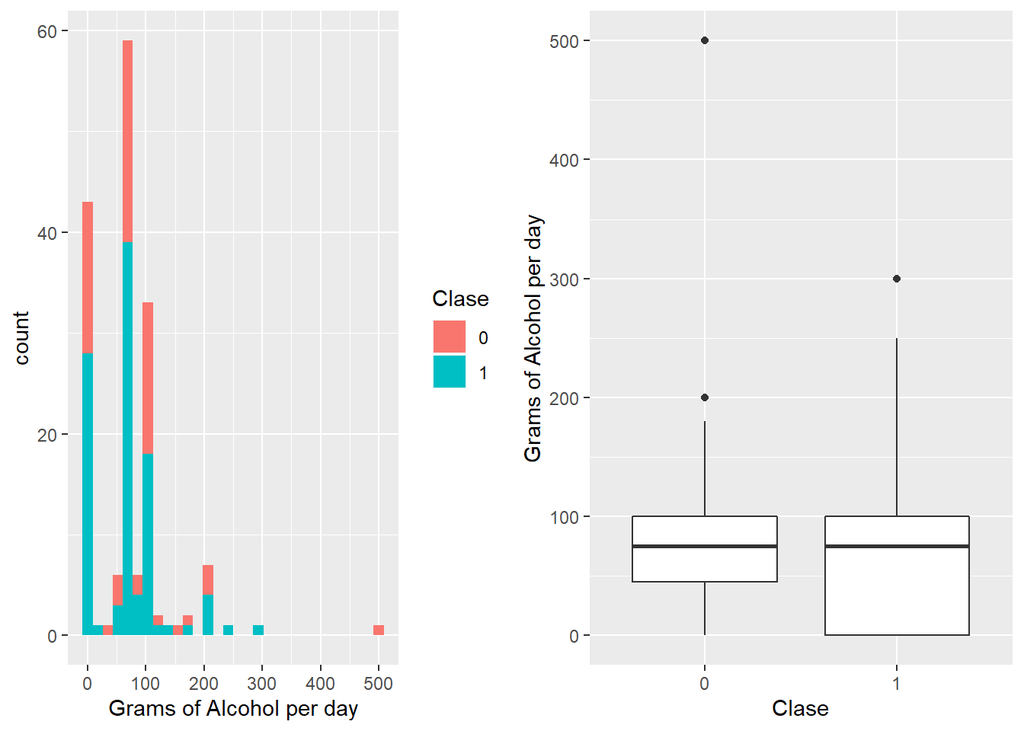

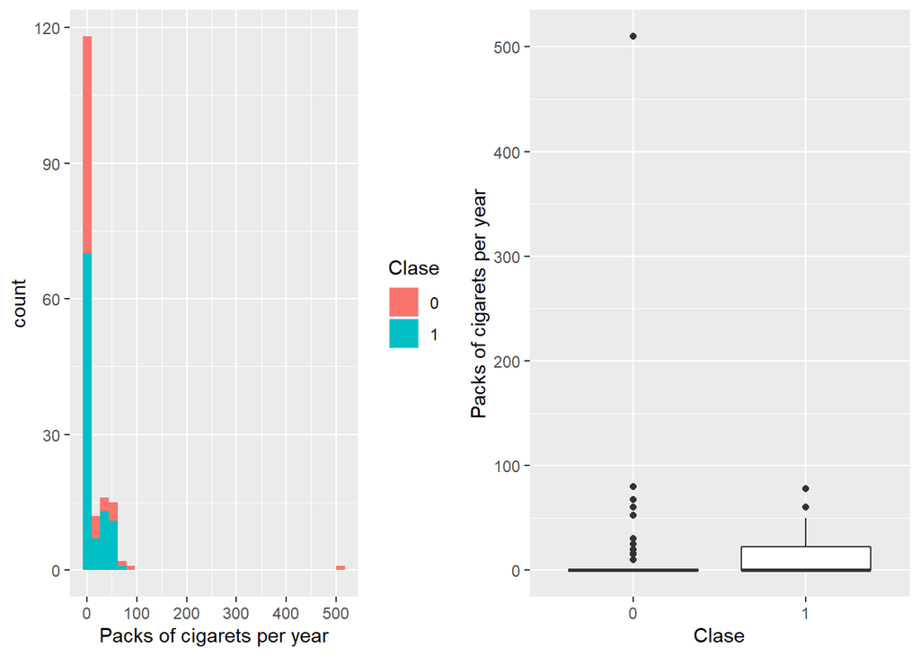

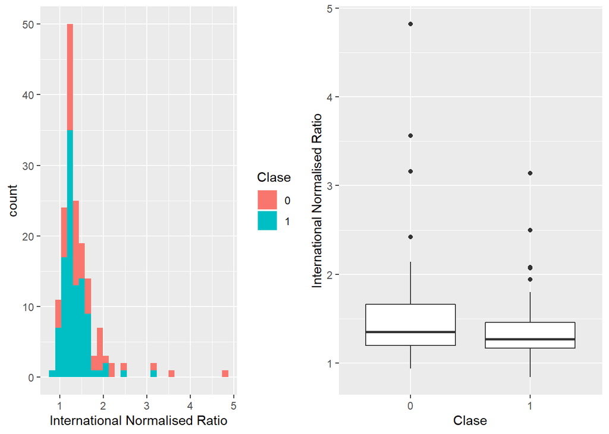

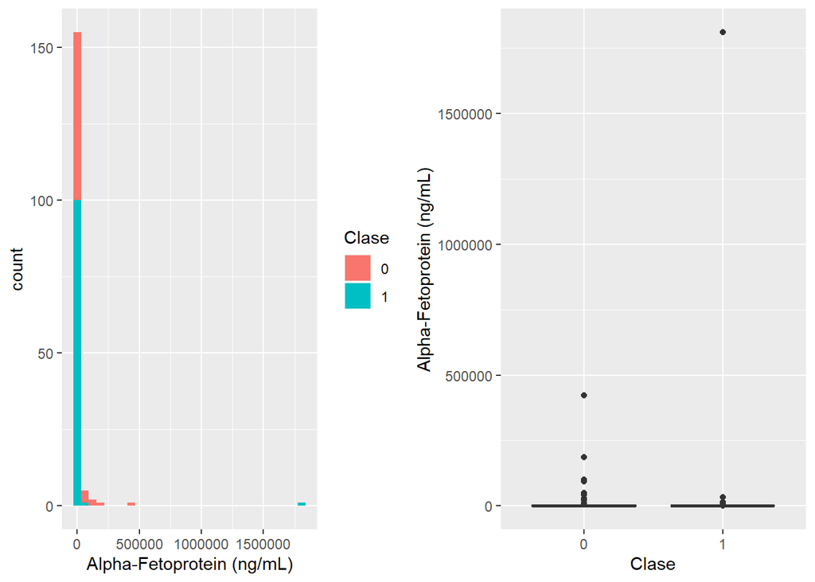

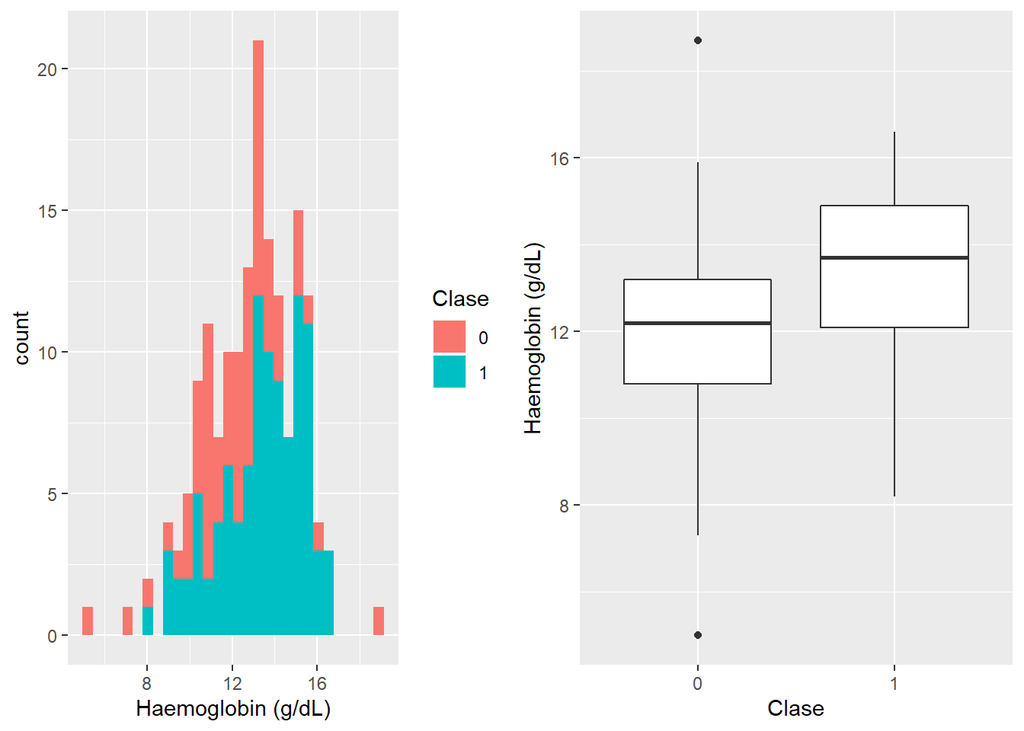

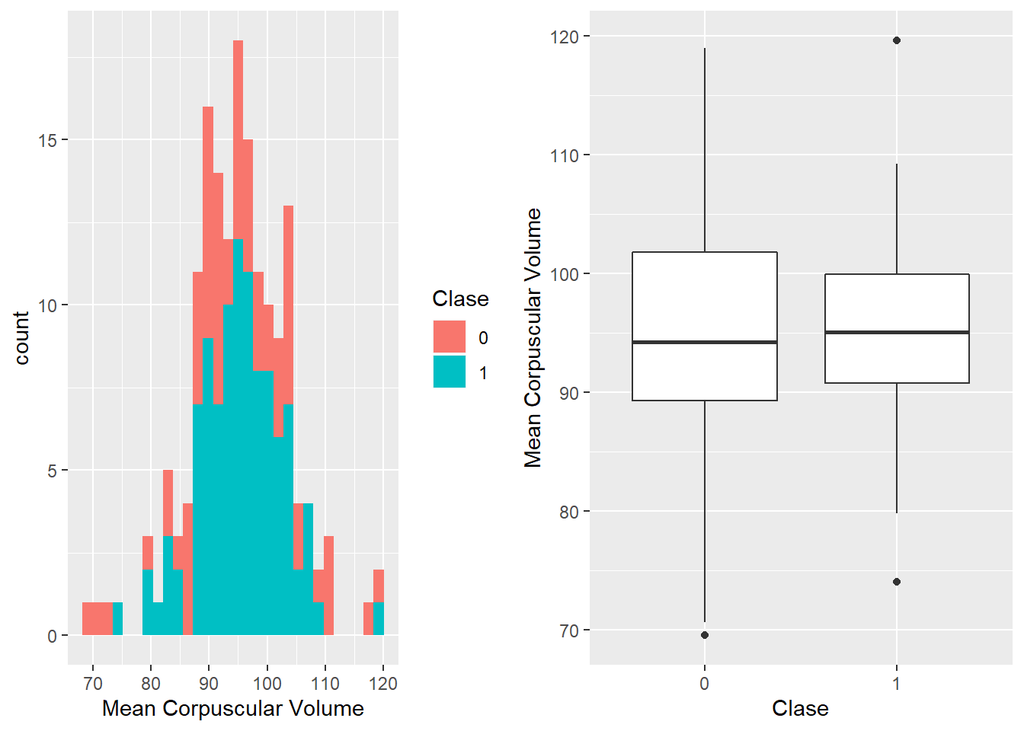

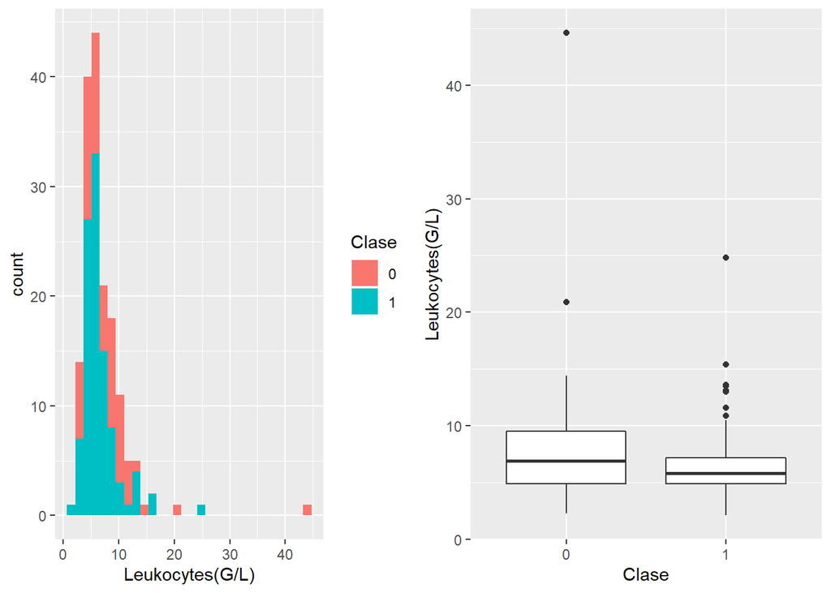

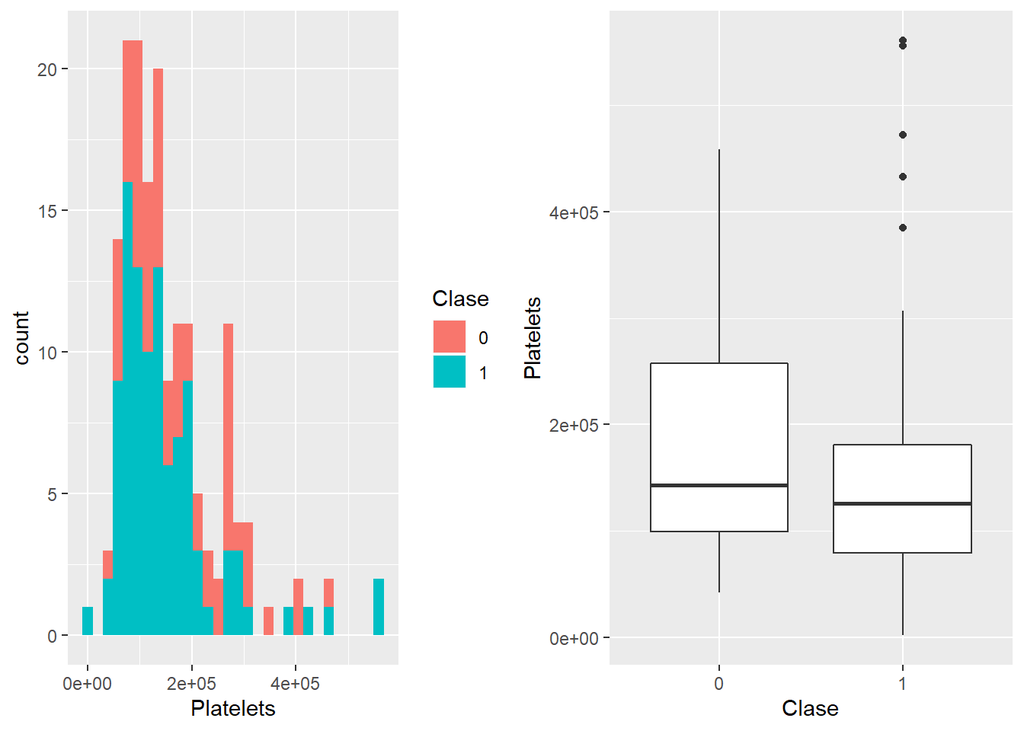

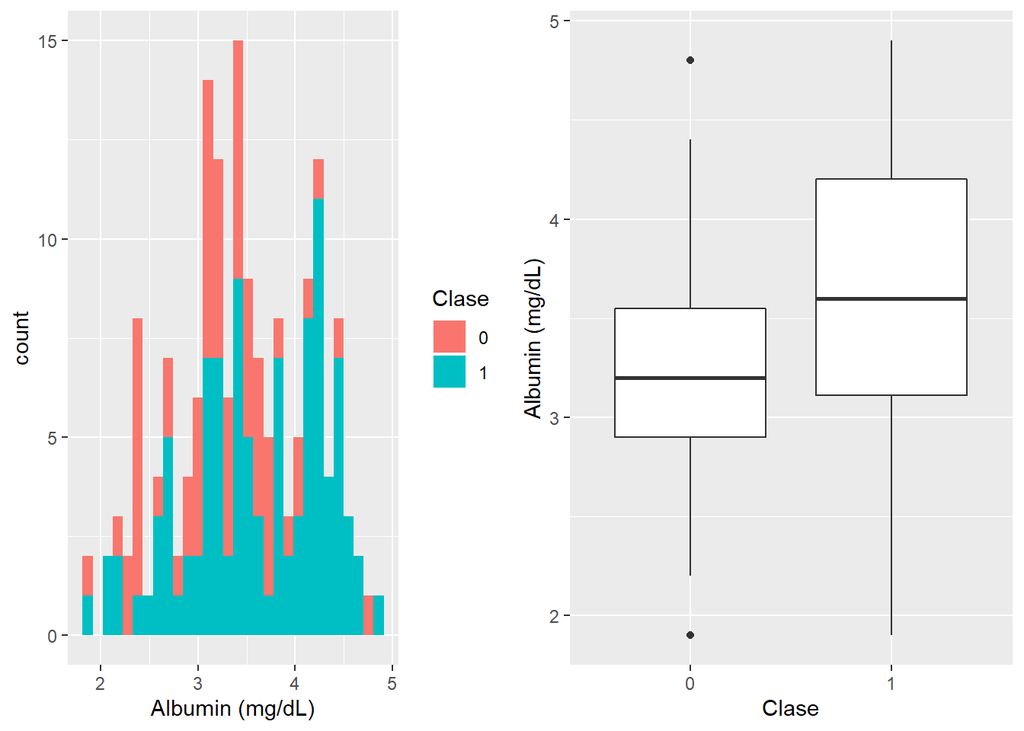

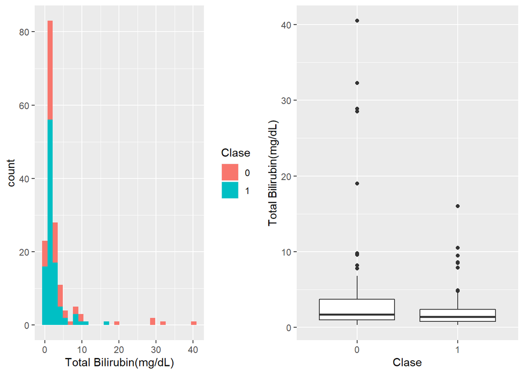

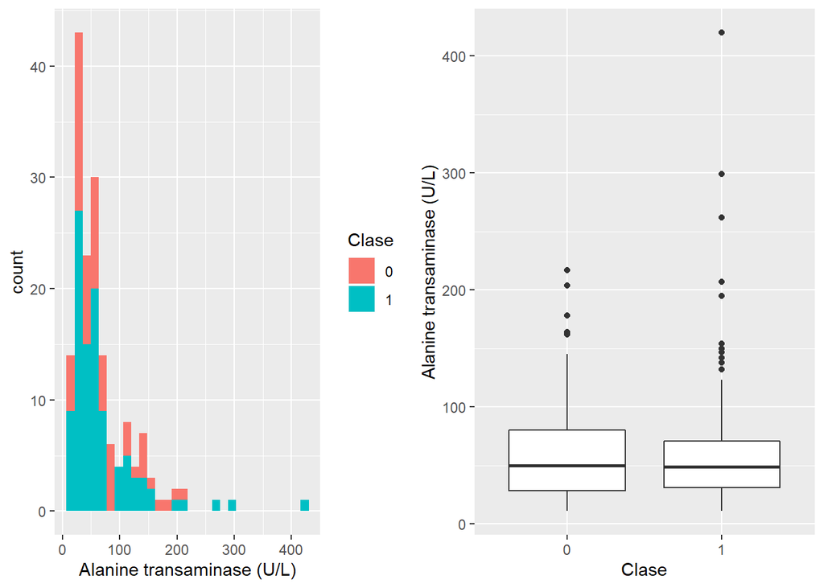

[11 more figures not shown]

```r
# Estudi distribució variables Numeriques
library(gridExtra)

for (i in hcc_num) {

  a1<-ggplot(hcc, aes(x=hcc[,i], fill=hcc$`Class Attribute`))+xlab(names(hcc)[i])+labs(fill="Clase")+geom_histogram()
  a2<-ggplot(hcc, aes(x=hcc$`Class Attribute`,y=hcc[,i]))+ylab(names(hcc)[i])+xlab("Clase")+geom_boxplot()

  grid.arrange(a1,a2,nrow=1)
}
```

Crida l’atenció vàries variables amb una distribució molt desplaçada cap a valors baixos però amb valors extrems alts. Molts son valors de laboratori, i sembla que s’adapten més a distribucions logarítmiques, per el que es modificaran. Aquestes variables son:

- Alpha-Fetoprotein (ng/mL)
- Total Bilirubin(mg/dL)
- Alanine transaminase (U/L)
- Aspartate transaminase (U/L)
- Gamma glutamyl transferase (U/L)
- Alkaline phosphatase (U/L)
- Total Proteins (g/dL)
- Creatinine (mg/dL)
- Direct Bilirubin (mg/dL)

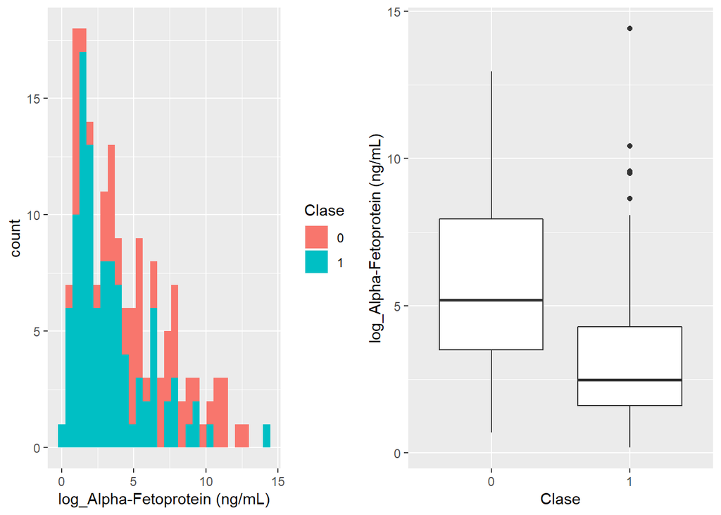

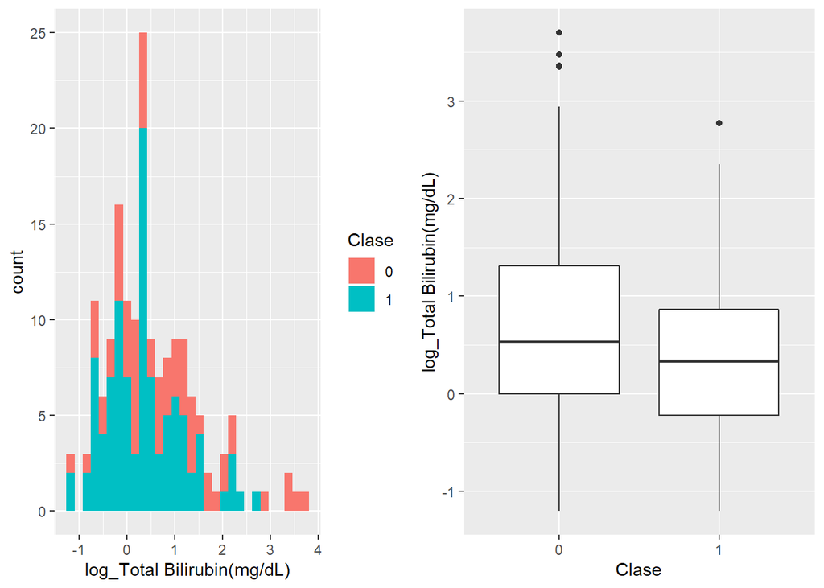

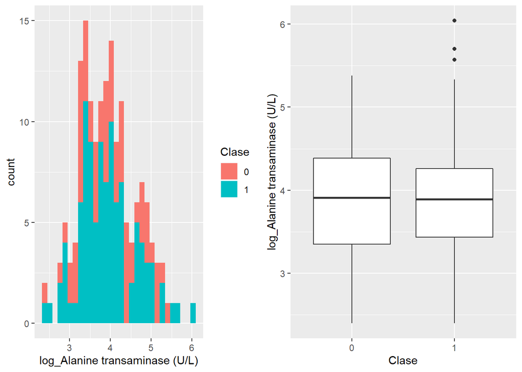

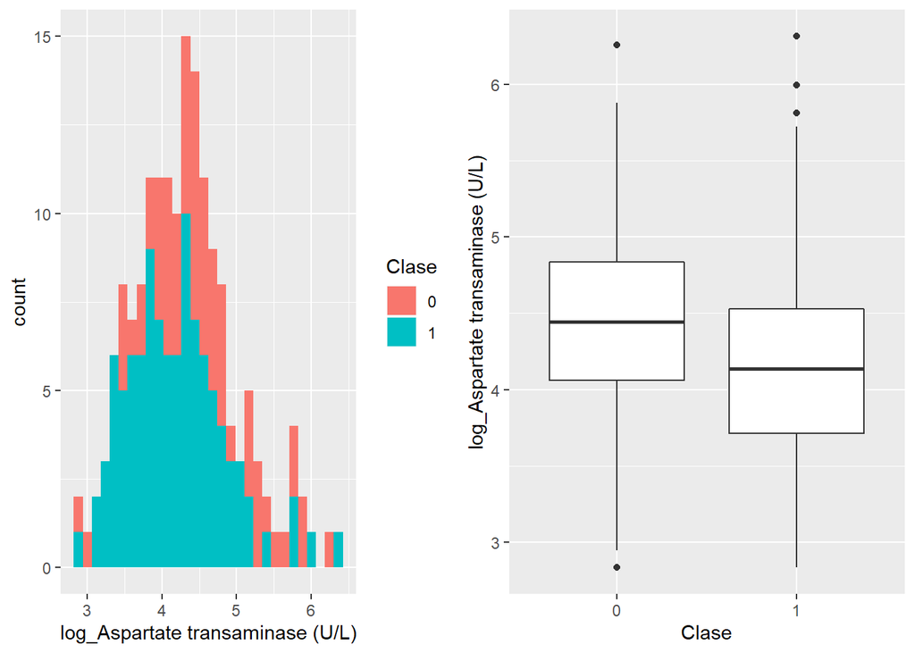

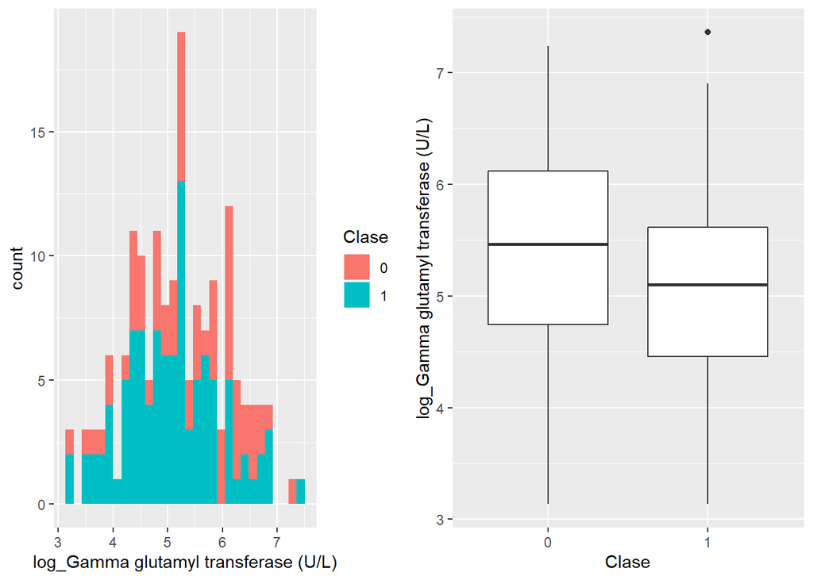

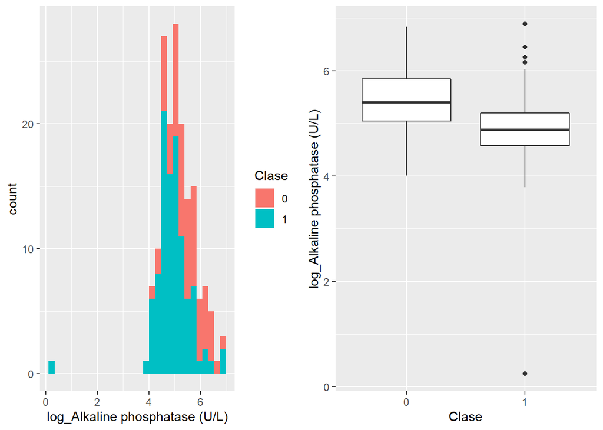

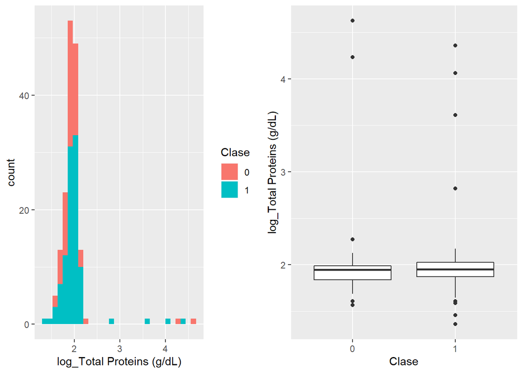

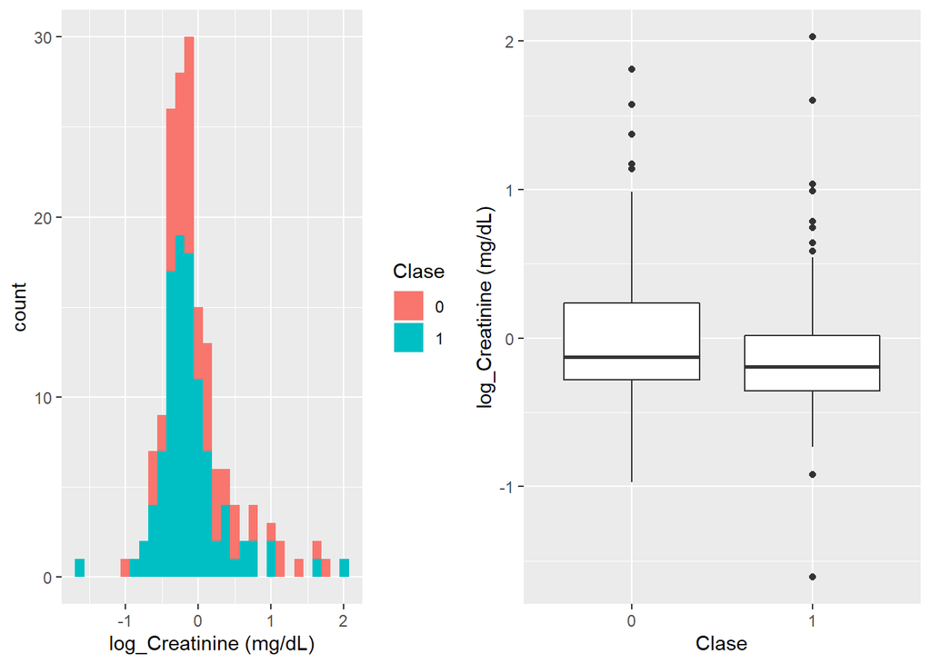

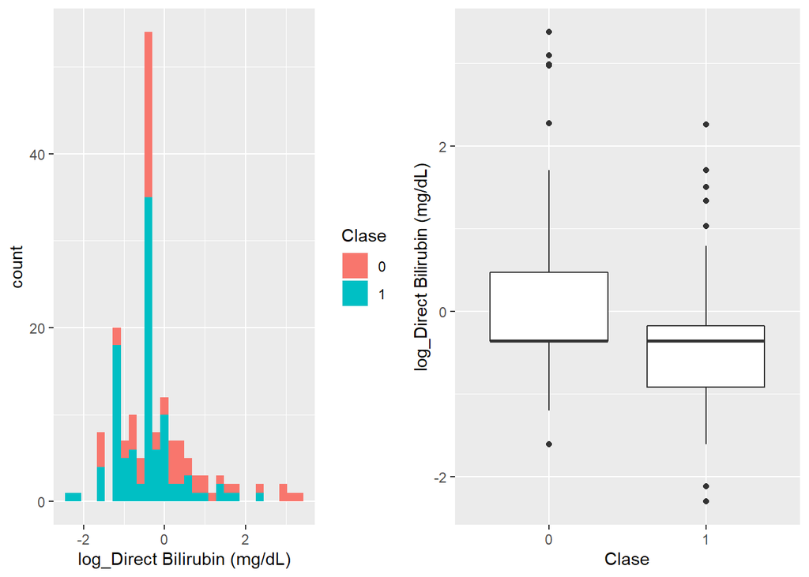

```r
# Transformació logarítmica de variables numériques
hcc_log<-c(31,37:43, 46)
for (i in hcc_log){
  hcc[,i]<-log(hcc[,i])
  names(hcc)[i]<-paste("log_",names(hcc)[i], sep="" )
}
for (i in hcc_log) {

  a1<-ggplot(hcc, aes(x=hcc[,i], fill=hcc$`Class Attribute`))+xlab(names(hcc)[i])+labs(fill="Clase")+geom_histogram()
  a2<-ggplot(hcc, aes(x=hcc$`Class Attribute`,y=hcc[,i]))+ylab(names(hcc)[i])+xlab("Clase")+geom_boxplot()

  grid.arrange(a1,a2,nrow=1)
}
```